# From Knowledge to Practice: Analyzing Contraceptive Behavior Among Reproductive-Age Women in Malawi Using DHS Data

Rokaya AITLHAJ-MHAND

2025-07-04

## INTRODUCTION

Despite global advancements in reproductive health, many low- and middle-income countries continue to face significant challenges in family planning uptake and utilization. Sub-Saharan Africa, in particular, reports persistently high fertility rates and low contraceptive prevalence, contributing to unintended pregnancies, maternal morbidity, and socio-economic instability. Malawi, a landlocked country in southeastern Africa, exemplifies this trend, with a notable gap between knowledge of contraception and its actual use among women of reproductive age (15–49 years). According to the Demographic and Health Surveys (DHS), awareness of modern contraceptive methods in Malawi is nearly universal. However, the translation of this knowledge into consistent and effective contraceptive practice remains uneven across different population groups. Factors such as age, education, marital status, place of residence, religion, and economic status play crucial roles in shaping individual decisions about contraceptive use. Understanding these dynamics is essential for tailoring public health interventions that address both informational and structural barriers to contraceptive access and use.

**Aim** This study aims to examine how contraceptive knowledge translates into contraceptive practice among reproductive-age women (15–49 years) in Malawi. Specifically, it seeks to analyze how sociodemographic factors influence the gap between knowledge and actual use of contraception.

### **Overview of Demographic and Socioeconomic Characteristics of Women in Malawi**

Table 1 presents the distribution of key demographic and socioeconomic characteristics among 24,562 women of reproductive age in Malawi. The age groups are fairly evenly distributed, with the largest proportions in the youngest brackets: 15–19 years (21.5%) and 20–24 years (20.7%). Geographically, the majority of participants reside in the southern region (46.2%), followed by the central (34.3%) and northern regions (19.6%).

Religious affiliation is predominantly Christian, with 42.3% identifying as “other Christian,” 17.6% Catholic, and 15.8% CCAP. Muslims make up 11.1%, while other religions and those reporting no religion represent a small minority.

Education levels reveal that most women have attained primary education (61.2%), with smaller proportions having no education (11.3%), secondary education (24.7%), or higher education (2.8%).

The wealth index is relatively balanced across quintiles, though the richest group represents the largest segment (26.3%), and the poorest accounts for 17.4%.

Overall, this table highlights a predominantly young, married, and Christian population with varied educational attainment and socioeconomic status, reflecting the diverse profiles relevant for reproductive health and contraceptive use analyses in Malawi.

Table 1. Overview of Demographic and Socioeconomic Characteristics of Women in Malawi

| **Variable** | **N = 24,562**<sup>1</sup> |
| --- | --- |
| Age Group |  |
| 15-19 | 5,273.00 (21.47%) |
| 20-24 | 5,094.00 (20.74%) |
| 25-29 | 3,976.00 (16.19%) |
| 30-34 | 3,648.00 (14.85%) |
| 35-39 | 2,988.00 (12.17%) |
| 40-44 | 2,022.00 (8.23%) |
| 45-49 | 1,561.00 (6.36%) |
| Division |  |
| northern region | 4,803.00 (19.55%) |
| central region | 8,417.00 (34.27%) |
| southern region | 11,342.00 (46.18%) |
| Religion |  |
| catholic | 4,320.00 (17.59%) |
| ccap | 3,878.00 (15.79%) |
| anglican | 1,258.00 (5.12%) |
| seventh day adventist / baptist | 1,839.00 (7.49%) |
| other christian | 10,390.00 (42.30%) |
| muslim | 2,726.00 (11.10%) |
| no religion | 113.00 (0.46%) |
| other | 38.00 (0.15%) |
| Currently_Married |  |
| never in union | 5,326.00 (21.68%) |
| currently in union/living with a man | 15,952.00 (64.95%) |
| formerly in union/living with a man | 3,284.00 (13.37%) |
| Literacy |  |
| cannot read at all | 6,376.00 (25.96%) |
| able to read only parts of sentence | 2,202.00 (8.97%) |
| able to read whole sentence | 15,944.00 (64.91%) |
| no card with required language | 10.00 (0.04%) |
| blind/visually impaired | 30.00 (0.12%) |
| Marital_Status |  |
| never in union | 5,326.00 (21.68%) |
| married | 14,912.00 (60.71%) |
| living with partner | 1,040.00 (4.23%) |
| widowed | 742.00 (3.02%) |
| divorced | 1,237.00 (5.04%) |
| no longer living together/separated | 1,305.00 (5.31%) |
| Highest Education |  |
| no education | 2,779.00 (11.31%) |
| primary | 15,028.00 (61.18%) |
| secondary | 6,061.00 (24.68%) |
| higher | 694.00 (2.83%) |
| Wealth Index |  |
| poorest | 4,279.00 (17.42%) |
| poorer | 4,429.00 (18.03%) |
| middle | 4,508.00 (18.35%) |
| richer | 4,897.00 (19.94%) |
| richest | 6,449.00 (26.26%) |

<sup>1</sup> n (%)

### **Age distribution by contraceptive use status**

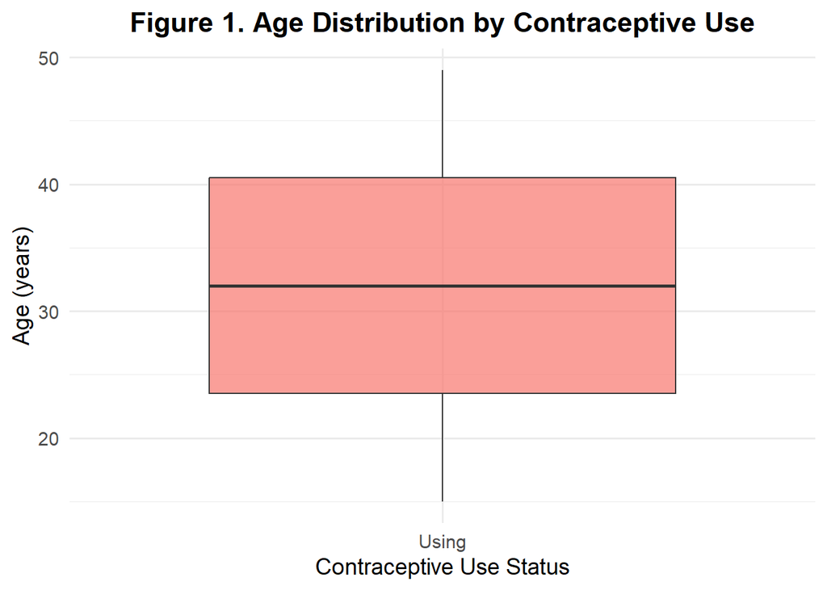

### **Contraceptive Use by Education Level**

The bar chart illustrates the distribution of contraceptive use among women in Malawi by education level. The variable displayed is the percentage of women currently using contraception.Among the women who reported using contraceptive methods, the majority had attained primary education (61.2%), followed by those with secondary education (24.7%). A smaller proportion of users had no formal education (11.3%), while only 2.8% had attained a higher (post-secondary) education.

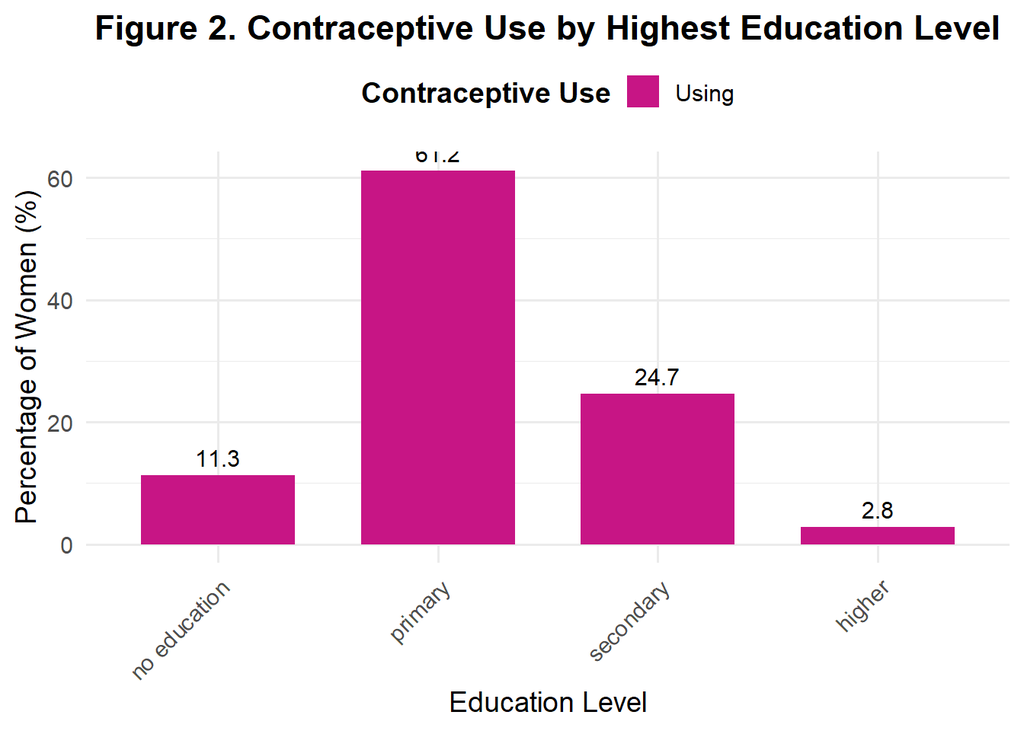

### **Contraceptive Method by Education levels**

The Barplot shows that Across all education levels, “not using” a contraceptive method remains the most common response, ranging from 52% to 61%. Among users, the most frequently reported method is injectable contraception, especially among women with primary education (24.4%) and no education (20.7%).

Use of implants and female sterilization follows, while methods like IUD, pill, and man condom are less common but more frequent among women with higher education. Traditional methods (e.g., withdrawal, periodic abstinence, SDM) and LAM are minimally used across all groups.

This suggests that method mix varies by educational level, with more method diversity and slightly higher use of modern short-acting and barrier methods among more educated women (Figure 3).

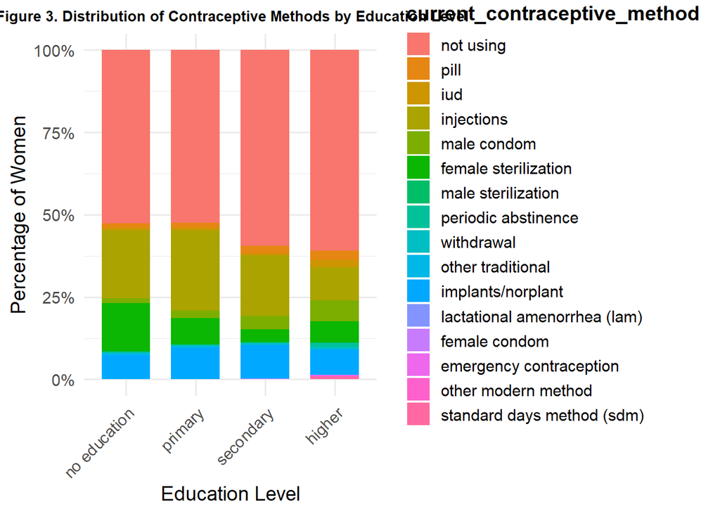

### **Contraceptive Use by wealth index group**

The barplot shows that The analysis of contraceptive use by wealth index group in Malawi reveals that a significant proportion of women across all socioeconomic strata are not using any contraceptive method, with non-use rates ranging from 51.6% among the poorer group to 56.7% among the richest. Modern contraceptive methods are the most commonly used among those practicing contraception, accounting for approximately 42% to 48% across all groups. Interestingly, modern method use does not increase steadily with wealth; in fact, usage is slightly higher among the poorer and middle groups than among the richest. Traditional and folkloric methods remain marginal, with usage rates below 1% in all quintiles. These findings suggest that while economic status plays a role, it may not be the sole determinant of contraceptive behavior, highlighting the importance of considering additional factors such as education, accessibility, cultural beliefs, and healthcare outreach (Figure 4).

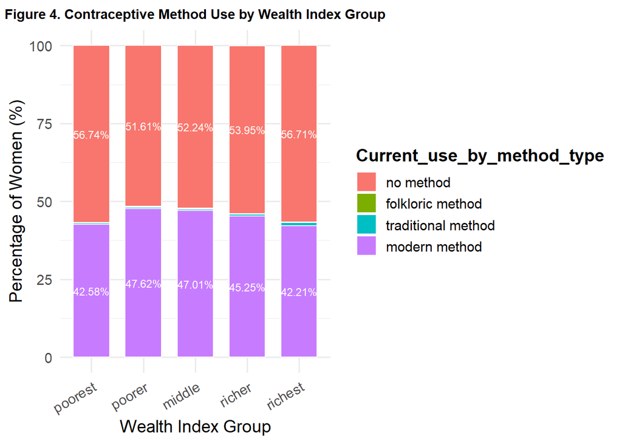

### **contraceptive methode by place residence**

Among women in Malawi, contraceptive use differs slightly between urban and rural areas. In urban areas, 42.6% of women use modern contraceptive methods, while 56.5% do not use any method. Traditional and folkloric methods are used by less than 1% each.

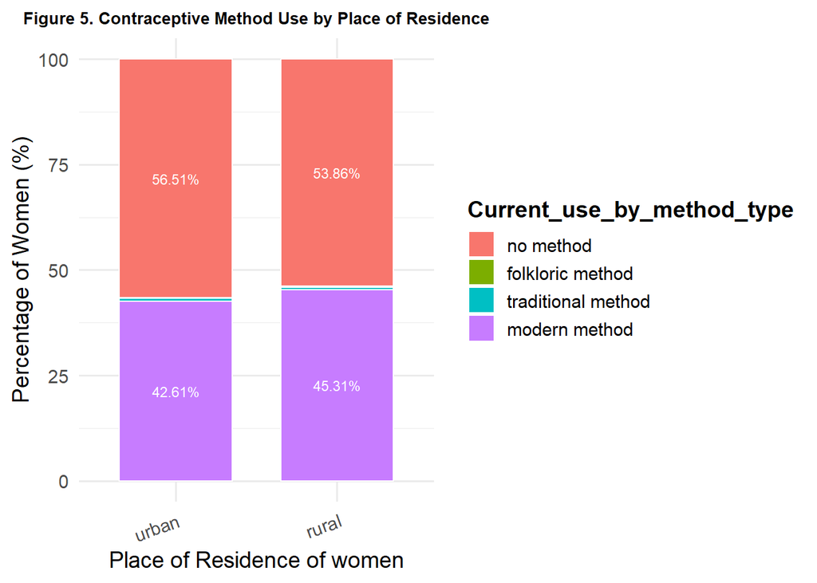

## **Conclusion**

These patterns emphasize that moving from **knowledge to practice** requires more than information dissemination. Structural, cultural, and accessibility-related barriers must be addressed. Tailored public health strategies that consider age, education, place of residence, and economic status are essential for closing the gap between contraceptive awareness and effective use, ultimately advancing reproductive health equity for women in Malawi.